# Advances in Agent-Based Big AI

Nuggets from the Summer

Charles F. Vardeman II

2024-09-13

## Advances in Agent-Based Big AI: Nuggets from Spring and Summer

- Welcome back, everyone!
- Overview of today’s presentation:
  - Latest advancements in conversational and agentic AI.
  - Notable updates from OpenAI and Google DeepMind.
  - Insights into agentic patterns and workflows.
  - Innovations in Graph-based retrieval models.
  - New frameworks like SciAgents and “HippoRAG”.

## Advances in Conversational Agentic AI

## Key Developments

- **Conversational and Agentic AI:**
  - Enhancements in dialogue management and contextual understanding.
  - Improved interaction capabilities, especially in handling complex, multi-turn conversations.
- **OpenAI’s Updates:**
  - Introduction of advanced multimodal models.
  - Focus on integrating visual and text-based inputs for richer interactions.
  - Expanded capabilities in workflow automation using AI agents.
  - Special Purpose Reasoning Model
- **Impact:**
  - Broader applications in customer service, virtual assistants, and content creation.
  - Better adaptability in real-world scenarios requiring nuanced understanding and interaction.

## Rise of ‘Conversational AI’ – OpenAI

[figure not shown]

[“Hello GPT-4o.” n.d. Accessed September 3, 2024.](https://openai.com/index/hello-gpt-4o/).

## Project Astra by Google DeepMind

[figure not shown]

[“Project Astra.” 2024. Google DeepMind. August 22, 2024.](https://deepmind.google/technologies/gemini/project-astra/).

[figure not shown]

[“Gemini Makes Your Mobile Device a Powerful AI Assistant.” 2024. Google. August 13, 2024.](https://blog.google/products/gemini/made-by-google-gemini-ai-updates/).

## Project Astra by Google DeepMind

- **Overview:**
  - Aims to develop proactive, teachable AI assistants.
  - Focus on integrating seamlessly across devices and platforms.
- **Key Features:**
  - Multimodal AI that understands and processes inputs like text, images, and audio.
  - Advanced context-awareness to anticipate user needs and provide relevant assistance.
- **Potential Applications:**
  - Could revolutionize how users interact with technology, making AI more accessible and useful in everyday tasks.

## Multi-Modal AI Models in Conversational Agents

## Driving the Development of Conversational Agents

- **What are Multi-Modal AI Models?**
  - AI models that process and integrate multiple types of data, such as text, images, audio, and video.
  - Examples include OpenAI’s GPT-4, Google’s Gemini, and DeepMind’s Project Astra.
- **Key Advantages:**
  - **Enhanced Understanding:** Ability to comprehend context from multiple data sources simultaneously, improving the accuracy and relevance of responses.
  - **Richer Interactions:** Enables more natural and intuitive interactions by combining visual, auditory, and textual cues.
  - **Broader Applications:** From customer service to personal assistants, these models are making AI interactions more versatile and effective.

## Driving the Development of Conversational Agents

- **Impact on Conversational Agents:**
  - **Improved Contextual Awareness:** Agents can better understand user needs by interpreting a broader range of input signals.
  - **Greater Personalization:** Tailors interactions to individual users by understanding nuances in visual and audio inputs.
  - **Advanced Capabilities:** Supports complex tasks such as visual question answering, interactive storytelling, and multimodal search.

## Driving the Development of Conversational Agents

- **Examples and Applications:**
  - **Virtual Assistants:** Google Assistant and Amazon Alexa integrating voice and image recognition for smart home management.
  - **Customer Service:** Chatbots that can handle text and visual content, enhancing user experience in e-commerce and tech support.
- **Future Directions:**
  - Ongoing research aims to further refine these models, making them more efficient and capable of real-time, multimodal interactions.
  - Potential for applications in areas like education, healthcare, and entertainment where diverse data types are crucial.

## Mistral Pixtral 12B

[figure not shown]

[Mistral releases Pixtral 12B, its first multimodal model](https://techcrunch.com/2024/09/11/mistral-releases-pixtral-its-first-multimodal-model/)

## Overview of Pixtral 12B

- **Introduction:**
  - Mistral’s first multimodal AI model, capable of processing both text and images.
  - Built on the Nemo 12B text model with an additional 400 million-parameter vision adapter.
- **Capabilities:**
  - Performs tasks such as image captioning, object counting, and answering image-related queries.
  - Vision encoding allows the model to “see” and process visual data alongside textual inputs.

## Google DataGemma

[figure not shown]

[DataGemma: Using real-world data to address AI hallucinations](https://blog.google/technology/ai/google-datagemma-ai-llm/)

## Google DataGemma Schema.org and KGs

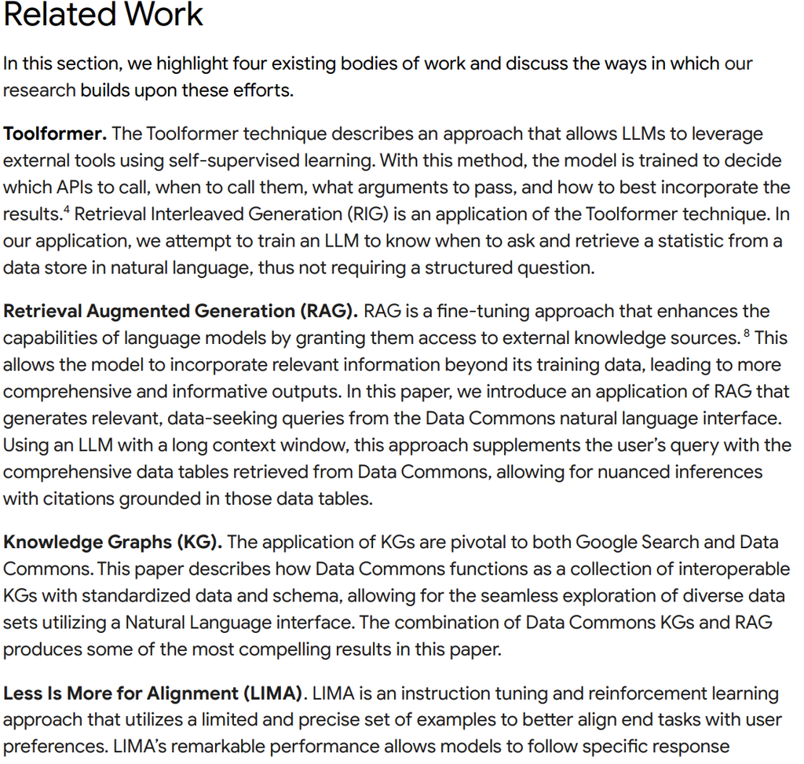

[Radhakrishnan, Prashanth, Jennifer Chen, Bo Xu, Prem Ramaswami, Adriana Olmos, James Manyika, and R V Guha. n.d. “Knowing When to Ask - Bridging Large Language Models and Data.”](https://docs.datacommons.org/papers/DataGemma-FullPaper.pdf)

## Models that Can “Reason”?

[figure not shown]

[Introducing OpenAI o1-preview: A new series of reasoning models for solving hard problems.](https://openai.com/index/introducing-openai-o1-preview/)

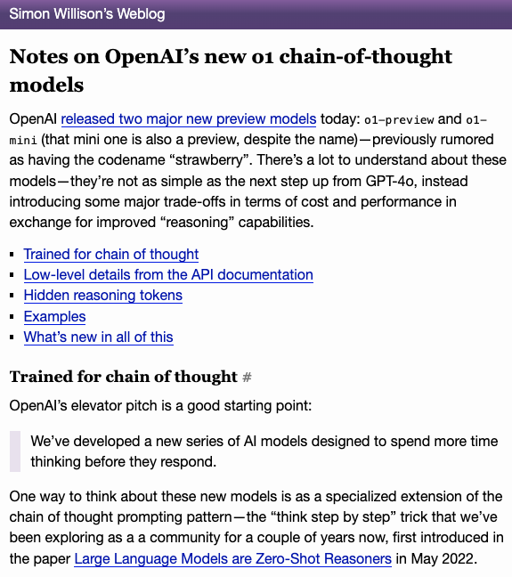

[“Notes on OpenAI’s New O1 Chain-of-Thought Models.” n.d. Accessed September 13, 2024. https://simonwillison.net/2024/Sep/12/openai-o1/.](https://simonwillison.net/2024/Sep/12/openai-o1/)

## Agentic Patterns and Workflows

## Generative Agents

[figure not shown]

[Generative Agents: Interactive Simulacra of Human Behavior](https://arxiv.org/pdf/2304.03442)

- [Google Illuminate AI Discussion](https://illuminate.google.com/papers?play=Mqs9Ge_ulG12)

## LLMs Based Autonomous Agents

[figure not shown]

[Wang, Lei, Chen Ma, Xueyang Feng, Zeyu Zhang, Hao Yang, Jingsen Zhang, Zhiyuan Chen, et al. 2024. “A Survey on Large Language Model Based Autonomous Agents.” Frontiers of Computer Science 18 (6): 186345. https://doi.org/10.1007/s11704-024-40231-1.](https://link.springer.com/article/10.1007/s11704-024-40231-1)

- [Google Illuminate AI Discussion](https://illuminate.google.com/library?play=PhFnDe_7yL7N)

## Andrew Ng’s Contributions to Agentic AI

[figure not shown]

[What’s next for AI agentic workflows ft. Andrew Ng of AI Fund](https://youtu.be/sal78ACtGTc?si=RKFXkcjWaPc_yxiZ)

## Andrew Ng’s Contributions to Agentic AI

- **Core Design Patterns:**
  - **Reflection:** Agents improve by critiquing their own outputs and iterating.
  - **Tool Use:** Integration of external tools for enhanced task performance.
  - **Planning:** Agents develop and follow strategic plans to achieve goals.
  - **Multi-agent Collaboration:** Systems of agents working together to solve complex problems.
- **Impact:**
  - Enhanced robustness and adaptability of AI systems.
  - Facilitates more effective problem-solving in dynamic environments.

## Agentic Workflows in 2024: The ultimate guide

[figure not shown]

[Agentic Workflows in 2024: The ultimate guide](https://www.vellum.ai/blog/agentic-workflows-emerging-architectures-and-design-patterns)

## Enhancing Retrieval with Graph-Based Models

- **GraphRAG by Microsoft Research:**
  - Combines knowledge graphs with Retrieval-Augmented Generation (RAG).
  - Uses structured data to improve retrieval accuracy and contextual relevance.
- **Key Features:**
  - **Whole-Data Reasoning:** Enables summarization and extraction of key themes from large datasets.
  - **Provenance Tracking:** Provides sources and grounding for AI-generated responses.
- **Benefits:**
  - Improved trust and verification in AI outputs.
  - Applicable in fields like data analysis, content generation, and decision support.

## Advances in GraphRAG

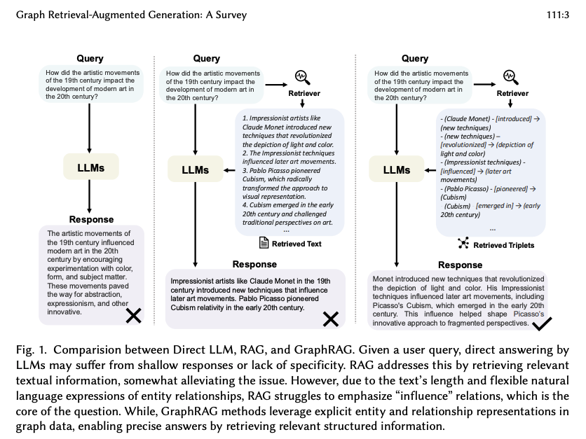

[Peng, Boci, Yun Zhu, Yongchao Liu, Xiaohe Bo, Haizhou Shi, Chuntao Hong, Yan Zhang, and Siliang Tang. 2024. “Graph Retrieval-Augmented Generation: A Survey.” arXiv. http://arxiv.org/abs/2408.08921.](http://arxiv.org/abs/2408.08921)

- [Google Illuminate Microsoft GraphRAG Paper](https://illuminate.google.com/library?play=n4RV5j_PQEW6)

## HippoRAG

[figure not shown]

[Gutiérrez, Bernal Jiménez, Yiheng Shu, Yu Gu, Michihiro Yasunaga, and Yu Su. 2024. “HippoRAG: Neurobiologically Inspired Long-Term Memory for Large Language Models.” arXiv. https://doi.org/10.48550/arXiv.2405.14831.](https://doi.org/10.48550/arXiv.2405.14831)

- [Google Illuminate](https://illuminate.google.com/library?play=0mwMvc_zIo421)

## HippoRAG: Enhanced Memory Integration for AI

- **Overview:**
  - Inspired by the hippocampal indexing theory of human memory.
  - Combines LLMs with knowledge graphs for enhanced information retrieval.
- **Methodology:**
  - **Offline Indexing:** Creates a hippocampal-like index using LLMs.
  - **Online Retrieval:** Uses Personalized PageRank to link queries to relevant knowledge nodes.
- **Performance:**
  - Outperforms traditional retrieval methods in multi-hop question answering.
  - More efficient, faster, and cost-effective than existing iterative retrieval techniques.

## SciAgents: Automating Scientific Discovery (“The OGRag”)

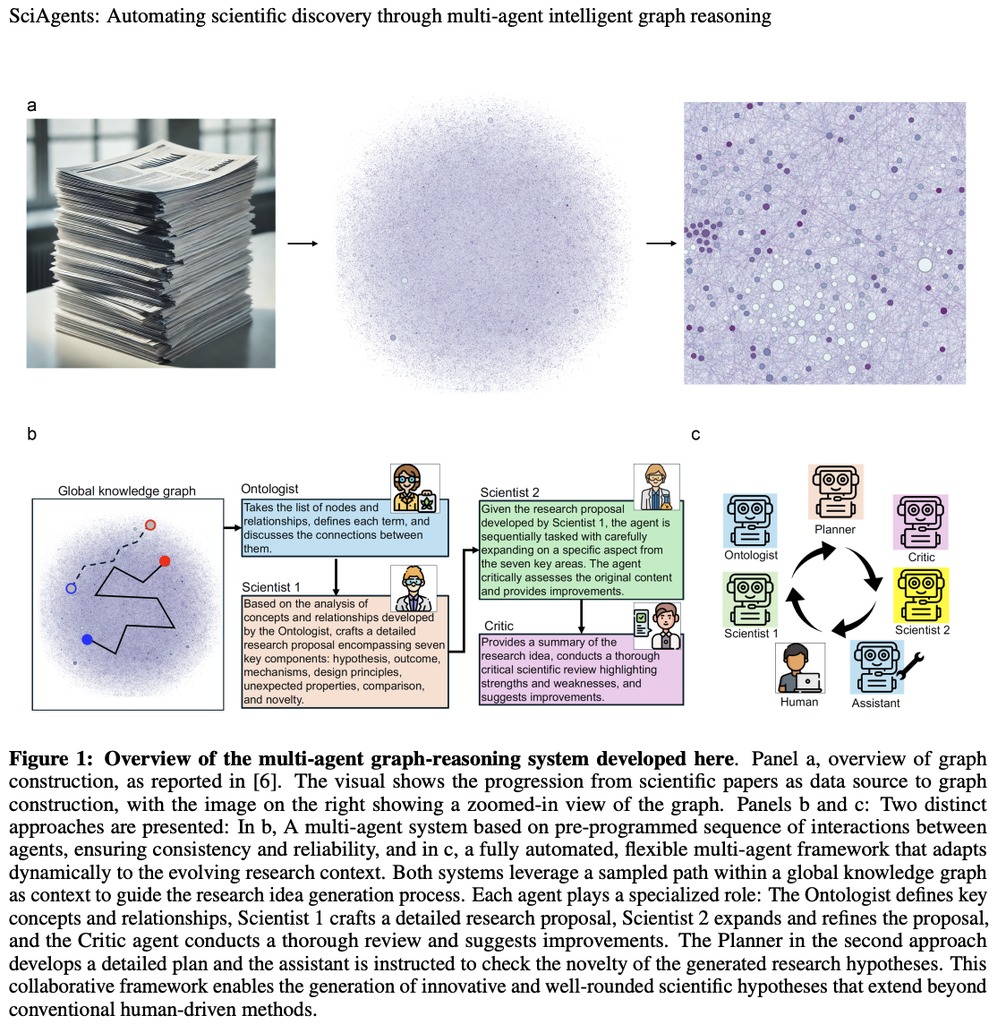

[Ghafarollahi, Alireza, and Markus J. Buehler. 2024. “SciAgents: Automating Scientific Discovery through Multi-Agent Intelligent Graph Reasoning.” arXiv. http://arxiv.org/abs/2409.05556.](http://arxiv.org/abs/2409.05556)

- [Google Illuminate](https://illuminate.google.com/library?play=Eqvand____fxx3)

## SciAgents Multi-Agent Intelligent Graph Reasoning

- **Introduction to SciAgents:**
  - Uses ontological knowledge graphs and multi-agent systems.
  - Designed to explore novel domains and discover hidden interdisciplinary connections.
- **Key Capabilities:**
  - Autonomous generation and refinement of research hypotheses.
  - Integration of up-to-date scientific data and critique of existing theories.
- **Case Studies:**
  - Demonstrated success in biologically inspired materials research.
  - Potential to accelerate scientific discovery across various domains.

# Wrap-Up and Discussion

[figure not shown]

Laboratory for Assured AI Application Development (LA3D)